# **NOTE:** Use File > Save a copy in Drive to make a copy before doing anything else

# Project 7: Data Exploration and Visualization

### Overview

In this project, you will apply data exploration and visualization techniques to a real-world dataset of your choice. You'll practice using pandas for data analysis and create meaningful visualizations to gain insights from your data. This project builds on your Python programming skills while introducing you to the exciting world of data science.

In [Lab7](https://colab.research.google.com/drive/15QvSh0csZaCU-OuuPIfpWx5wLDDjmqK4?usp=sharing), you explore the titanic dataset and you should use it as a sample and pick a dataset of your interest to do a similar data exploration and visualization.

### Project Objectives

- Find and select a dataset from a real-world data source
- Formulate a clear inquiry question based on your chosen dataset
- Perform exploratory data analysis using pandas functions
- Create at least two meaningful data visualizations
- Analyze your findings and answer your inquiry question
- Reflect on the insights gained through data exploration

### Data Sources

You can choose from various online data sources such as:

- [Kaggle](https://www.kaggle.com/datasets) - Wide variety of datasets
- [data.gov](https://www.data.gov/) - U.S. government data
- [Our World in Data](https://ourworldindata.org/) - Global development data
- [GitHub](https://github.com/datasets) - Curated datasets
- [Google Dataset Search](https://datasetsearch.research.google.com/) - Search for datasets
- Or any other reliable data source you find interesting

## Part 1: Dataset Selection and Initial Exploration

#### TODO Tasks:

1. Select Your Dataset: Choose a dataset that interests you. Make sure it has at least 100 rows and multiple columns with different data types (e.g., numerical, categorical, dates).

Please create either text or code cells in between the TODO tasks to do the work.

2. Import Libraries: Import the necessary libraries (pandas, matplotlib, seaborn) at the beginning of your notebook by creating code cells below this text cell.

```python
import pandas as pd
import seaborn as sns
import matplotlib.pyplot as plt
```

3. Load Your Data: Load your chosen dataset using pandas and save it to a pandas dataframe. Please create a code cell below this text cell to do it.

```python
from google.colab import drive
drive.mount('/content/drive')
file_path = '/content/drive/My Drive/Colab Notebooks/enhanced_student_habits_performance_dataset.csv' # **UPDATE THIS PATH**
df = pd.read_csv(file_path)
print("Dataset loaded successfully.")
print(df.head())
```

```
Dataset loaded successfully.
   student_id  age  gender             major  study_hours_per_day  \
0      100000   26    Male  Computer Science             7.645367
1      100001   28    Male              Arts             5.700000
2      100002   17    Male              Arts             2.400000
3      100003   27   Other        Psychology             3.400000
4      100004   25  Female          Business             4.700000

   social_media_hours  netflix_hours part_time_job  attendance_percentage  \
0                 3.0            0.1           Yes                   70.3
1                 0.5            0.4            No                   88.4
2                 4.2            0.7            No                   82.1
3                 4.6            2.3           Yes                   79.3
4                 0.8            2.7           Yes                   62.9

```

[output cut: 22 more lines]

4. Data Summary: Use the following functions to do inital exploration your dataset:
- info() - Display information about the dataset structure
- describe() - Show statistical summary of numerical columns
- head() - Display the first 5 rows (df.head())
- shape - Show the dimensions of the dataset (e.g. df.shape)
- columns - Get the column names (e.g. df.columns)

You may use 5 code cells below this text cell to accomplish it.

```python
df.info()
```

```
<class 'pandas.core.frame.DataFrame'>
RangeIndex: 80000 entries, 0 to 79999
Data columns (total 31 columns):
 #   Column                         Non-Null Count  Dtype
---  ------                         --------------  -----
 0   student_id                     80000 non-null  int64
 1   age                            80000 non-null  int64
 2   gender                         80000 non-null  object
 3   major                          80000 non-null  object
 4   study_hours_per_day            80000 non-null  float64
 5   social_media_hours             80000 non-null  float64
 6   netflix_hours                  80000 non-null  float64
 7   part_time_job                  80000 non-null  object
 8   attendance_percentage          80000 non-null  float64
 9   sleep_hours                    80000 non-null  float64
```

[output cut: 23 more lines]

```python
df.describe()
```

|  | student_id | age | study_hours_per_day | social_media_hours | netflix_hours | attendance_percentage | sleep_hours | exercise_frequency | mental_health_rating | previous_gpa | semester | stress_level | social_activity | screen_time | parental_support_level | motivation_level | exam_anxiety_score | time_management_score | exam_score |
| --- | --- | --- | --- | --- | --- | --- | --- | --- | --- | --- | --- | --- | --- | --- | --- | --- | --- | --- | --- |
| count | 80000.000000 | 80000.000000 | 80000.000000 | 80000.000000 | 80000.000000 | 80000.000000 | 80000.000000 | 80000.000000 | 80000.000000 | 80000.000000 | 80000.000000 | 80000.000000 | 80000.000000 | 80000.000000 | 80000.000000 | 80000.000000 | 80000.000000 | 80000.000000 | 80000.000000 |
| mean | 139999.500000 | 22.004288 | 4.174388 | 2.501366 | 1.997754 | 69.967884 | 7.017417 | 3.516587 | 6.804107 | 3.602448 | 4.497338 | 5.012478 | 2.500225 | 9.673029 | 5.479438 | 5.488525 | 8.508475 | 5.499132 | 89.141350 |
| std | 23094.155105 | 3.745570 | 2.004135 | 1.445441 | 1.155992 | 17.333015 | 1.467377 | 2.291575 | 1.921579 | 0.462876 | 2.295312 | 1.953174 | 1.704292 | 2.780869 | 2.873327 | 2.867782 | 1.796411 | 2.603534 | 11.591497 |
| min | 100000.000000 | 16.000000 | 0.000000 | 0.000000 | 0.000000 | 40.000000 | 4.000000 | 0.000000 | 1.000000 | 1.640000 | 1.000000 | 1.000000 | 0.000000 | 0.300000 | 1.000000 | 1.000000 | 5.000000 | 1.000000 | 36.000000 |
| 25% | 119999.750000 | 19.000000 | 2.800000 | 1.200000 | 1.000000 | 55.000000 | 6.000000 | 2.000000 | 5.500000 | 3.270000 | 2.000000 | 3.600000 | 1.000000 | 7.800000 | 3.000000 | 3.000000 | 7.000000 | 3.200000 | 82.000000 |
| 50% | 139999.500000 | 22.000000 | 4.125624 | 2.500000 | 2.000000 | 69.900000 | 7.000000 | 4.000000 | 6.900000 | 3.790000 | 5.000000 | 5.000000 | 2.000000 | 9.700000 | 5.000000 | 5.000000 | 10.000000 | 5.500000 | 93.000000 |
| 75% | 159999.250000 | 25.000000 | 5.500000 | 3.800000 | 3.000000 | 84.900000 | 8.000000 | 6.000000 | 8.200000 | 4.000000 | 7.000000 | 6.400000 | 4.000000 | 11.600000 | 8.000000 | 8.000000 | 10.000000 | 7.800000 | 100.000000 |
| max | 179999.000000 | 28.000000 | 12.000000 | 5.000000 | 4.000000 | 100.000000 | 12.000000 | 7.000000 | 10.000000 | 4.000000 | 8.000000 | 10.000000 | 5.000000 | 21.000000 | 10.000000 | 10.000000 | 10.000000 | 10.000000 | 100.000000 |

```python
df.head()
```

|  | student_id | age | gender | major | study_hours_per_day | social_media_hours | netflix_hours | part_time_job | attendance_percentage | sleep_hours | ... | screen_time | study_environment | access_to_tutoring | family_income_range | parental_support_level | motivation_level | exam_anxiety_score | learning_style | time_management_score | exam_score |
| --- | --- | --- | --- | --- | --- | --- | --- | --- | --- | --- | --- | --- | --- | --- | --- | --- | --- | --- | --- | --- | --- |
| 0 | 100000 | 26 | Male | Computer Science | 7.645367 | 3.0 | 0.1 | Yes | 70.3 | 6.2 | ... | 10.9 | Co-Learning Group | Yes | High | 9 | 7 | 8 | Reading | 3.0 | 100 |
| 1 | 100001 | 28 | Male | Arts | 5.700000 | 0.5 | 0.4 | No | 88.4 | 7.2 | ... | 8.3 | Co-Learning Group | Yes | Low | 7 | 2 | 10 | Reading | 6.0 | 99 |
| 2 | 100002 | 17 | Male | Arts | 2.400000 | 4.2 | 0.7 | No | 82.1 | 9.2 | ... | 8.0 | Library | Yes | High | 3 | 9 | 6 | Kinesthetic | 7.6 | 98 |
| 3 | 100003 | 27 | Other | Psychology | 3.400000 | 4.6 | 2.3 | Yes | 79.3 | 4.2 | ... | 11.7 | Co-Learning Group | Yes | Low | 5 | 3 | 10 | Reading | 3.2 | 100 |
| 4 | 100004 | 25 | Female | Business | 4.700000 | 0.8 | 2.7 | Yes | 62.9 | 6.5 | ... | 9.4 | Quiet Room | Yes | Medium | 9 | 1 | 10 | Reading | 7.1 | 98 |

5 rows × 31 columns

```python
df.shape
```

```
(80000, 31)
```

```python
df.columns
```

```
Index(['student_id', 'age', 'gender', 'major', 'study_hours_per_day',
       'social_media_hours', 'netflix_hours', 'part_time_job',
       'attendance_percentage', 'sleep_hours', 'diet_quality',
       'exercise_frequency', 'parental_education_level', 'internet_quality',
       'mental_health_rating', 'extracurricular_participation', 'previous_gpa',
       'semester', 'stress_level', 'dropout_risk', 'social_activity',
       'screen_time', 'study_environment', 'access_to_tutoring',
       'family_income_range', 'parental_support_level', 'motivation_level',
       'exam_anxiety_score', 'learning_style', 'time_management_score',
       'exam_score'],
      dtype='object')
```

5. Inquiry Question: Write a clear, specific question that you want to answer using your dataset by creating a text cell below and **write the question in bold please.**

For example:

- "How has the average temperature changed in major cities over the past decade?"
- "What factors are most strongly correlated with housing prices?"
- "Is there a relationship between education level and income?"

**Is there a relationship between exam anxiety and hours spent studying, and what is their correlation to exam scores?**

## Part 2: Data Visualization and Analysis

#### TODO Tasks:

1. Data Cleaning (if necessary): Check for and handle any missing values, duplicates, or data quality issues.

**NOTE: This could be a daunting task even for seasoned data scientists. My suggestion is to use a dataset that is already clean if you can for the purpose of completing this assignment in a week.**

Examples:

- Checking for missing values: df.isnull().sum()
- Dropping rows with any missing values: df.dropna(inplace=True)
- Dropping columns with all missing values: df.dropna(axis=1, how='all', inplace=True)
- Removing duplicate row: df.drop_duplicates(inplace=True)

```python
df.isnull().sum()
# no missing values, but dropping student ID because it is unnecessary #
df = df.drop('student_id', axis=1)
df.head()
```

|  | age | gender | major | study_hours_per_day | social_media_hours | netflix_hours | part_time_job | attendance_percentage | sleep_hours | diet_quality | ... | screen_time | study_environment | access_to_tutoring | family_income_range | parental_support_level | motivation_level | exam_anxiety_score | learning_style | time_management_score | exam_score |
| --- | --- | --- | --- | --- | --- | --- | --- | --- | --- | --- | --- | --- | --- | --- | --- | --- | --- | --- | --- | --- | --- |
| 0 | 26 | Male | Computer Science | 7.645367 | 3.0 | 0.1 | Yes | 70.3 | 6.2 | Poor | ... | 10.9 | Co-Learning Group | Yes | High | 9 | 7 | 8 | Reading | 3.0 | 100 |
| 1 | 28 | Male | Arts | 5.700000 | 0.5 | 0.4 | No | 88.4 | 7.2 | Good | ... | 8.3 | Co-Learning Group | Yes | Low | 7 | 2 | 10 | Reading | 6.0 | 99 |
| 2 | 17 | Male | Arts | 2.400000 | 4.2 | 0.7 | No | 82.1 | 9.2 | Good | ... | 8.0 | Library | Yes | High | 3 | 9 | 6 | Kinesthetic | 7.6 | 98 |
| 3 | 27 | Other | Psychology | 3.400000 | 4.6 | 2.3 | Yes | 79.3 | 4.2 | Fair | ... | 11.7 | Co-Learning Group | Yes | Low | 5 | 3 | 10 | Reading | 3.2 | 100 |
| 4 | 25 | Female | Business | 4.700000 | 0.8 | 2.7 | Yes | 62.9 | 6.5 | Good | ... | 9.4 | Quiet Room | Yes | Medium | 9 | 1 | 10 | Reading | 7.1 | 98 |

5 rows × 30 columns

2. Create Visualizations: Create at least 2 different types of visualizations that help answer your research question. Choose from:
- Bar charts
- Line plots
- Scatter plots
- Histograms
- Box plots
- Heatmaps
- Any other appropriate visualization

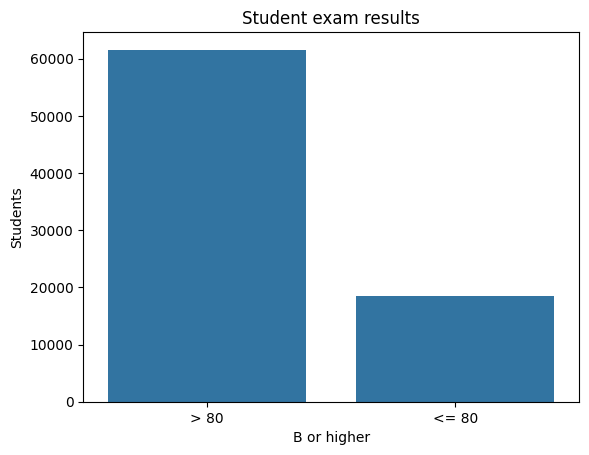

```python
# Using a countplot to seperate exam score into a more clear good or bad result #
df['B'] = df['exam_score'].apply(lambda x: '> 80' if x > 80 else '<= 80')
sns.countplot(x='B', data=df)
plt.title("Student exam results")
plt.xlabel("B or higher")
plt.ylabel("Students")

plt.show()
```

3. Customize Your Plots: Make sure your visualizations are clear and informative by:
- Adding appropriate titles
- Labeling axes
- Using colors effectively
- Adding legends when necessary

Please create code cells below this to create your visualizations.

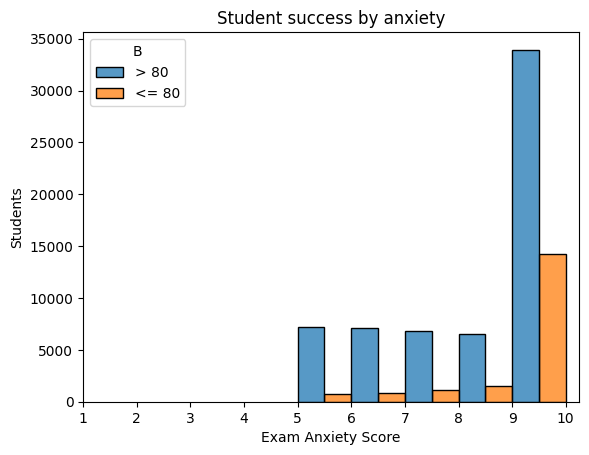

```python
#historgram showing exam anxiety score and comparing how many students got above or below 80% per anxiety score#
sns.histplot(x='exam_anxiety_score', data=df, hue='B', multiple="dodge",bins=5)
plt.title('Student success by anxiety')
plt.xlabel('Exam Anxiety Score')
plt.ylabel('Students')
plt.xticks([1, 2, 3, 4, 5, 6, 7, 8, 9, 10],['1', '2', '3', '4', '5', '6', '7', '8', '9', '10'])
plt.show()
```

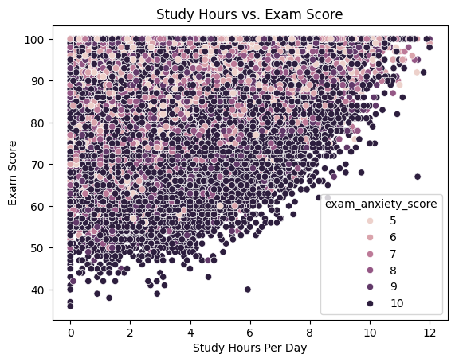

```python
#scatterplot showing study hours vs exam score, and color coding exam anxiety #
sns.scatterplot(x='study_hours_per_day', y='exam_score', data=df, hue='exam_anxiety_score')
plt.title('Study Hours vs. Exam Score')
plt.xlabel('Study Hours Per Day')
plt.ylabel('Exam Score')
plt.show()
```

4. Analysis: Write 1-2 paragraphs discussing:
- Whether your research question can be answered with the available data
- What insights you discovered through your visualizations
- Any unexpected or interesting findings
- Limitations of your analysis
- Suggestions for further investigation

Please create a text cell below this cell to write your analysis.

Exam anxiety seems to have some corretlation to exam score, while study hours per day was a bit less clear, but still showed correlation. The exam anxiety also does not seem to have much correlation with study hours per day. The historgram plot shows that the majority of people who got below an 80 had a exam anxiety score of 10, and number of people got below an 80 gradually increased as exam anxiety went up, with a final large jump at 10. It is also really interesting that 0 people gave an exam anxiety score of below 5. The scatterplot also confirms that people with less exam anxiety tend to do better. Study hours is all over the place, since people who scored 80 and above had a variety of study hours, from 0 to 12, though more people who studied less than 6 hours had scores under 70 and people who studied more than that. It's interesting that the extremes are all over the place, with 0 hours of study resulting in all exam scores and a score of 100 resulting from all hours of study, but fewer from people who studied over 11 hours. So people who studied the most were less likely to get a low score, but also less likely to get 100. Some of the limitations to this analysis could actually be the size of the sample, because it makes the scatterplot somewhat difficult to read. The data is also from all students across multiple classes, and I'm not sure if this is all data for the same exam or not, which could also change results, since some exams are harder, some require less hours of study, and some might be considered more of a priority for some students over others, as well as the difference in teachers giving exam prep. It may help to break up the data with more variables, like separating the students by major or class.

## NOTE: If you use a local dataset, you MUST submit the dataset along with your notebook to get credit.

- Download your notebook as CS110_Project7.ipynb
- Ensure all TODO tasks are completed
- Make sure your code runs without errors
- Include clear comments explaining your work
- Submit the notebook file

## Grading Criteria (4 points)

- Dataset Selection: Appropriate choice of dataset with sufficient complexity
- Inquiry Question: Clear, specific, and answerable with the chosen data
- Data Exploration: Proper use of pandas functions for initial analysis
- Visualizations: At least 2 clear, well-formatted, and relevant plots
- Analysis: Thoughtful interpretation of findings and answer to research question
- Code Quality: Clean, commented, and well-organized code

Remember: The goal is not just to create visualizations, but to use them to gain meaningful insights about your data. Think like a data scientist and let your curiosity guide your exploration!